# **Predicting Championship Title Wins in League of Legends**

# **Introduction**

League of Legends (often referred to as League), in its most played gamemode is an online 5 versus 5 Multiplayer Online Battle Arena (MOBA) game that has attracted millions of fans all of the world since its realease in 2009. The game hosts a roster of over 150 unique playable characters, or champions, each having their own unique skills and abilities for fans to pilot. Entering the game, each team of five is split into different roles across a map consisting of three "lanes" that players can march down to do battle, with large dark "jungle" separating each lane. The overall goal of each match of League of Legends is to march down a lane, defeat your opponents in battle, and destroy the enemy structures blocking each lane. A team wins once they are the first to destroy all the enemy structures in at least one lane, reaching the opponent's base, reffered to as the nexus, and destroy it to end the game.

The MOBA genre began as a user created gamemode for the popular Real Time Strategy (RTS) game StarCraft. In this mode, players controlled a strong character that would march alongside weaker computer controlled units to do battle against a powerful computer controlled enemy. This idea inspired a similar fanmade gamemode for another RTS called Warcraft III. This second fanmade gamemode was called Defense of the Ancients (DotA), and it was this game that lead to the massively popular sequel DotA II along with DotA's spiritual sequel: League of Legends.

League of Legends and DotA II have developed into serious competitors in the online gaming market, and have risen to become some of the most played games year after year for roughly the past decade. They have grown to the point where large professional scenes have risen for each game, with League of Legends being one of the most popular eSports ever. The League professional scene consists of 12 different regions across the world that host a multitude of teams playing regular matches on a weekly basis. The year is split into two seasons called "splits": a Spring split and a Summer split. Each region ends their splits deciding one team to be the champion for that split, and then twice a year the top teams from each region come together to compete in massive global tournaments. These tournaments include the Mid Season Invitational ("MSI", occuring after Spring) and the much larger World Championship ("Worlds", hosted after Summer). The two global tournaments garner millions of viewers and offer millions of dollars in prize money to teams that succeed. In 2019 and 2020, the World Championship events peaked at 44 and 45 million concurrent viewers respectively. League of Legends eSports events have given over $60 million in prize money to date (Gough) and in some regions teams have been franchised for in the millions of dollars.

In this overall analysis, we wish to garner insights through analyzing data collected in a large dataset of almost every professional League of Legends match played in the years 2015 to 2018. With this data, we can potentially notice trends in which specific teams or regions win the most. We may also be able to use match data to predict which team would win each of the major regional or global tournament events.

Gough, C. (2022, February 15). LoL Tournaments Prize Money 2021. Statista. Retrieved May 13, 2022, from https://www.statista.com/statistics/807925/lol-tournament-prize-pool/

### **Data Collection**

The dataset being analyzed is listed for public download on Kaggle at https://www.kaggle.com/datasets/chuckephron/leagueoflegends?resource=download. The dataset contains match data from 2015 to 2018 across all global regions. The dataset is fairly expansive, however some of the column data includes: region of play, year of match, which split of that year (Spring or Summer), wether the game was playoff or regular season, which teams played, which team won, among many more key pieces of data.

We can download the full dataset from the Kaggle website listing. Doing this gives us an archive of multiple CSV formatted files containing every datapoint we need:

[figure not shown]

We can now add the LeagueofLegends.csv dataset file into our workspace that contains most of the information and begin our data collection using Pandas python tools.

```python
# First, we import necessary libraries for our analysis
import pandas as pd
import numpy as np
import matplotlib.pyplot as plt
from sklearn.linear_model import LinearRegression
from sklearn.metrics import mean_squared_error
```

```python
#Then, we want to create Pandas dataframes from the dataset files we wish to analyze:
LeagueCSV = "LeagueofLegends.csv"

data = pd.read_csv(LeagueCSV)
data
```

|  | League | Year | Season | Type | blueTeamTag | bResult | rResult | redTeamTag | gamelength | golddiff | ... | redMiddleChamp | goldredMiddle | redADC | redADCChamp | goldredADC | redSupport | redSupportChamp | goldredSupport | redBans | Address |
| --- | --- | --- | --- | --- | --- | --- | --- | --- | --- | --- | --- | --- | --- | --- | --- | --- | --- | --- | --- | --- | --- |
| 0 | NALCS | 2015 | Spring | Season | TSM | 1 | 0 | C9 | 40 | [0, 0, -14, -65, -268, -431, -488, -789, -494,... | ... | Fizz | [475, 475, 552, 842, 1178, 1378, 1635, 1949, 2... | Sneaky | Sivir | [475, 475, 532, 762, 1097, 1469, 1726, 2112, 2... | LemonNation | Thresh | [515, 515, 577, 722, 911, 1042, 1194, 1370, 14... | ['Tristana', 'Leblanc', 'Nidalee'] | http://matchhistory.na.leagueoflegends.com/en/... |
| 1 | NALCS | 2015 | Spring | Season | CST | 0 | 1 | DIG | 38 | [0, 0, -26, -18, 147, 237, -152, 18, 88, -242,... | ... | Azir | [475, 475, 552, 786, 1097, 1389, 1660, 1955, 2... | CoreJJ | Corki | [475, 475, 532, 868, 1220, 1445, 1732, 1979, 2... | KiWiKiD | Annie | [515, 515, 583, 752, 900, 1066, 1236, 1417, 15... | ['RekSai', 'Janna', 'Leblanc'] | http://matchhistory.na.leagueoflegends.com/en/... |
| 2 | NALCS | 2015 | Spring | Season | WFX | 1 | 0 | GV | 40 | [0, 0, 10, -60, 34, 37, 589, 1064, 1258, 913, ... | ... | Azir | [475, 475, 533, 801, 1006, 1233, 1385, 1720, 1... | Cop | Corki | [475, 475, 533, 781, 1085, 1398, 1782, 1957, 2... | BunnyFuFuu | Janna | [515, 515, 584, 721, 858, 1002, 1168, 1303, 14... | ['Leblanc', 'Zed', 'RekSai'] | http://matchhistory.na.leagueoflegends.com/en/... |
| 3 | NALCS | 2015 | Spring | Season | TIP | 0 | 1 | TL | 41 | [0, 0, -15, 25, 228, -6, -243, 175, -346, 16, ... | ... | Lulu | [475, 475, 532, 771, 1046, 1288, 1534, 1776, 2... | KEITH | KogMaw | [475, 475, 532, 766, 1161, 1438, 1776, 1936, 2... | Xpecial | Janna | [515, 515, 583, 721, 870, 1059, 1205, 1342, 15... | ['RekSai', 'Rumble', 'LeeSin'] | http://matchhistory.na.leagueoflegends.com/en/... |
| 4 | NALCS | 2015 | Spring | Season | CLG | 1 | 0 | T8 | 35 | [40, 40, 44, -36, 113, 158, -121, -191, 23, 20... | ... | Lulu | [475, 475, 532, 807, 1042, 1338, 1646, 1951, 2... | Maplestreet8 | Corki | [475, 475, 532, 792, 1187, 1488, 1832, 2136, 2... | Dodo8 | Annie | [475, 475, 538, 671, 817, 948, 1104, 1240, 136... | ['Rumble', 'Sivir', 'Rengar'] | http://matchhistory.na.leagueoflegends.com/en/... |
| ... | ... | ... | ... | ... | ... | ... | ... | ... | ... | ... | ... | ... | ... | ... | ... | ... | ... | ... | ... | ... | ... |
| 7615 | TCL | 2018 | Spring | Season | YC | 0 | 1 | SUP | 34 | [0, 0, -18, -95, 45, -87, -117, 199, 126, 92, ... | ... | Veigar | [500, 500, 632, 982, 1258, 1667, 2060, 2390, 2... | Zeitnot | Xayah | [500, 500, 564, 1027, 1320, 1727, 1963, 2276, ... | SnowFlower | Rakan | [500, 500, 566, 801, 1004, 1234, 1463, 1674, 1... | ['Ornn', 'Kalista', 'Ryze', 'Alistar', 'Shen'] | https://matchhistory.euw.leagueoflegends.com/e... |
| 7616 | TCL | 2018 | Spring | Season | GAL | 0 | 1 | DP | 39 | [0, 0, -86, -39, -207, -349, -60, -140, 187, -... | ... | Ryze | [500, 500, 612, 1000, 1193, 1626, 1979, 2318, ... | Ruvelius | Caitlyn | [500, 500, 621, 977, 1420, 1809, 2047, 2413, 2... | Japone | Braum | [500, 500, 587, 790, 1107, 1335, 1472, 1616, 1... | ['Zoe', 'KogMaw', 'JarvanIV', 'Ornn', 'Rengar'] | https://matchhistory.euw.leagueoflegends.com/e... |
| 7617 | OPL | 2018 | Spring | Season | SIN | 0 | 1 | DW | 24 | [0, -8, -6, 116, 103, -92, -470, -958, -1998, ... | ... | Malzahar | [500, 500, 615, 903, 1225, 1617, 1976, 2304, 2... | k1ng | Ezreal | [500, 508, 592, 986, 1400, 1753, 2196, 2538, 3... | Cupcake | Taric | [500, 500, 585, 770, 976, 1222, 1446, 1627, 19... | ['Azir', 'Kalista', 'Braum', 'Maokai', 'Alistar'] | https://matchhistory.na.leagueoflegends.com/en... |
| 7618 | OPL | 2018 | Spring | Season | LGC | 1 | 0 | TTC | 35 | [0, 0, -97, 33, 351, 284, 299, 263, 403, 623, ... | ... | Veigar | [500, 500, 561, 931, 1223, 1631, 1987, 2315, 2... | Low | Sivir | [500, 500, 634, 930, 1304, 1691, 2042, 2384, 2... | Tilting | Janna | [500, 500, 592, 788, 1006, 1251, 1490, 1704, 1... | ['Kalista', 'Galio', 'Gnar', 'Jayce', 'Sejuani'] | https://matchhistory.na.leagueoflegends.com/en... |
| 7619 | OPL | 2018 | Spring | Season | TTC | 0 | 1 | LGC | 42 | [0, 0, -8, -225, -36, 73, 464, 184, 1171, 1409... | ... | Malzahar | [500, 500, 598, 968, 1165, 1477, 1801, 2016, 2... | Raid | Vayne | [500, 500, 587, 954, 1327, 1749, 2007, 2471, 2... | Decoy | Braum | [500, 500, 585, 793, 998, 1201, 1373, 1619, 18... | ['KogMaw', 'Illaoi', 'Azir', 'Karma', 'Sejuani'] | https://matchhistory.na.leagueoflegends.com/en... |

7620 rows × 57 columns

What we have done here is create a Pandas Dataframe from our CSV data file. In this Dataframe, we can see that we have 7620 rows which means that the set includes data from over 7600 professional League matches. We also see that there are 57 columns, each holding a different group of datapoints from each match. It would be hard to manually list them all. Luckily our dataset includes a CSV file with descriptions of each column. We can take the information from said CSV below:

```python
columnCSV = "_columns.csv"

colData = pd.read_csv(columnCSV)
colData
```

|  | ColumnName | ColumnDescription |
| --- | --- | --- |
| 0 | Address | website address the data is scraped from \n |
| 1 | League | League or Tournament the match took place in \n |
| 2 | Year | Year the match took place in \n |
| 3 | Season | Spring or Summer depending on which half of th... |
| 4 | Type | Season, Playoffs, Regional, or International m... |
| 5 | blueTeamTag | Blue Team's tag name (ex. Team SoloMid is TSM... |
| 6 | bResult | Result of the match for Blue Team - 1 is a wi... |
| 7 | rResult | Result of the match for Red Team - 1 is a win... |
| 8 | redTeamTag | Red Team's Tag Name (ex. Team SoloMid is TSM) \n |
| 9 | gamelength | Game length in minutes \n |
| 10 | golddiff | Gold difference - computed Blue minus Red - b... |
| 11 | goldblue | Blue Team's total gold value by minute \n |
| 12 | bKills | List of Blue Team's kills - [Time in minutes,... |
| 13 | bTowers | List of minutes that Blue Team destroyed a to... |
| 14 | bInhibs | List of minutes that Blue Team destroyed an i... |
| 15 | bDragons | List of minutes that Blue Team killed a drago... |
| 16 | bBarons | List of minutes that Blue Team killed a baron... |
| 17 | bHeralds | List of minutes that Blue Team killed a rift ... |
| 18 | goldred | Red Team's total gold value by minute \n |
| 19 | rKills | List of Red Team's kills - [Time in minutes, ... |
| 20 | rTowers | List of minutes that Red Team destroyed a tow... |
| 21 | rInhibs | List of minutes that Red Team destroyed an in... |
| 22 | rDragons | List of minutes that Red Team killed a dragon... |
| 23 | rBarons | List of minutes that Red Team killed a baron ... |
| 24 | rHeralds | List of minutes that Red Team killed a rift h... |
| 25 | blueTop | Name of Blue Team's player in the top positio... |
| 26 | blueTopChamp | Name of Blue Team's champion in the top posit... |
| 27 | goldblueTop | Blue's Top position player's gold value by mi... |
| 28 | blueJungle | Name of Blue Team's player in the jungle posi... |
| 29 | blueJungleChamp | Name of Blue Team's champion in the jungle po... |
| 30 | goldblueJungle | Blue's Jungle position player's gold value by... |
| 31 | blueMiddle | Name of Blue Team's player in the middle posi... |
| 32 | blueMiddleChamp | Name of Blue Team's champion in the middle po... |
| 33 | goldblueMiddle | Blue's Middle position player's gold value by... |
| 34 | blueADC | Name of Blue Team's player in the ADC positio... |
| 35 | blueADCChamp | Name of Blue Team's champion in the ADC posit... |
| 36 | goldblueADC | Blue's ADC position player's gold value by mi... |
| 37 | blueSupport | Name of Blue Team's player in the support pos... |
| 38 | blueSupportChamp | Name of Blue's champion in the support positi... |
| 39 | goldblueSupport | Blue's Support player's gold value by minute \n |
| 40 | blueBans | List of champions Blue Team banned (in order) \n |
| 41 | redTop | Name of Red Team's player in the top position \n |
| 42 | redTopChamp | Name of Red Team's champion in the top positi... |
| 43 | goldredTop | Red's Top position player's gold value by min... |
| 44 | redJungle | Name of Red Team's player in the jungle posit... |
| 45 | redJungleChamp | Name of Red Team's champion in the jungle pos... |
| 46 | goldredJungle | Red's Jungle position player's gold value by ... |
| 47 | redMiddle | Name of Red Team's player in the middle posit... |
| 48 | redMiddleChamp | Name of Red Team's champion in the middle pos... |
| 49 | goldredMiddle | Red's Middle position player's gold value by ... |
| 50 | redADC | Name of Red Team's player in the ADC position \n |
| 51 | redADCChamp | Name of Red Team's champion in the ADC positi... |
| 52 | goldredADC | Red's ADC position player's gold value by min... |
| 53 | redSupportChamp | Name of Red Team's player in the support posi... |
| 54 | redSupport | Name of Red Team's champion in the support po... |
| 55 | goldredSupport | Red's Support position player's gold value by... |
| 56 | redBans | List of champions Red Team banned (in order) |

Looking over this data, we can see things such as the league and when the match was played, team and player names, who won, along with interesting statistics to analyze such as how much gold each player collected and the champion they are playing. In League of Legends, gold can be gained from defeating other players, enemy structures, and computer controlled units on the map. Gold is used to buy items to make your character stronger, so gold (especially team total gold) can be an important indicator to predict which team is curring winning the match.

### **Data Manipulation and Representation**

Due to the expansive nature of the dataset, we can represent the set in many ways. Depending on the analysis you wish to do, you may want to drop some of the unnecessary columns from the dataset to make it a bit simpler. Maybe you also want to take a subset of the rows of the dataset. Lets say we only want to analyze games in one region, we can make a table with only these rows. A couple of examples of these types of manipulations are included below, however for this analysis we are leaving the set the way it is in order to have the maximum amount of datapoints possible.

```python
#Dropping a column or so
#data = data.drop(columns = ["someColumn", "otherColumn"])

#Taking a subset of the data, say for one region
#data = data[ (data["League"] == "LEC") ]
```

One quick thing we do want to do is add a column that combines the year and split to easily analyze seasons separately across time:

```python
#New column for combined year and split designation
data["yearSplit"] = data["Year"].astype(str) + " " + data["Season"]
data.head(10)
```

|  | League | Year | Season | Type | blueTeamTag | bResult | rResult | redTeamTag | gamelength | golddiff | ... | goldredMiddle | redADC | redADCChamp | goldredADC | redSupport | redSupportChamp | goldredSupport | redBans | Address | yearSplit |
| --- | --- | --- | --- | --- | --- | --- | --- | --- | --- | --- | --- | --- | --- | --- | --- | --- | --- | --- | --- | --- | --- |
| 0 | NALCS | 2015 | Spring | Season | TSM | 1 | 0 | C9 | 40 | [0, 0, -14, -65, -268, -431, -488, -789, -494,... | ... | [475, 475, 552, 842, 1178, 1378, 1635, 1949, 2... | Sneaky | Sivir | [475, 475, 532, 762, 1097, 1469, 1726, 2112, 2... | LemonNation | Thresh | [515, 515, 577, 722, 911, 1042, 1194, 1370, 14... | ['Tristana', 'Leblanc', 'Nidalee'] | http://matchhistory.na.leagueoflegends.com/en/... | 2015 Spring |
| 1 | NALCS | 2015 | Spring | Season | CST | 0 | 1 | DIG | 38 | [0, 0, -26, -18, 147, 237, -152, 18, 88, -242,... | ... | [475, 475, 552, 786, 1097, 1389, 1660, 1955, 2... | CoreJJ | Corki | [475, 475, 532, 868, 1220, 1445, 1732, 1979, 2... | KiWiKiD | Annie | [515, 515, 583, 752, 900, 1066, 1236, 1417, 15... | ['RekSai', 'Janna', 'Leblanc'] | http://matchhistory.na.leagueoflegends.com/en/... | 2015 Spring |
| 2 | NALCS | 2015 | Spring | Season | WFX | 1 | 0 | GV | 40 | [0, 0, 10, -60, 34, 37, 589, 1064, 1258, 913, ... | ... | [475, 475, 533, 801, 1006, 1233, 1385, 1720, 1... | Cop | Corki | [475, 475, 533, 781, 1085, 1398, 1782, 1957, 2... | BunnyFuFuu | Janna | [515, 515, 584, 721, 858, 1002, 1168, 1303, 14... | ['Leblanc', 'Zed', 'RekSai'] | http://matchhistory.na.leagueoflegends.com/en/... | 2015 Spring |
| 3 | NALCS | 2015 | Spring | Season | TIP | 0 | 1 | TL | 41 | [0, 0, -15, 25, 228, -6, -243, 175, -346, 16, ... | ... | [475, 475, 532, 771, 1046, 1288, 1534, 1776, 2... | KEITH | KogMaw | [475, 475, 532, 766, 1161, 1438, 1776, 1936, 2... | Xpecial | Janna | [515, 515, 583, 721, 870, 1059, 1205, 1342, 15... | ['RekSai', 'Rumble', 'LeeSin'] | http://matchhistory.na.leagueoflegends.com/en/... | 2015 Spring |
| 4 | NALCS | 2015 | Spring | Season | CLG | 1 | 0 | T8 | 35 | [40, 40, 44, -36, 113, 158, -121, -191, 23, 20... | ... | [475, 475, 532, 807, 1042, 1338, 1646, 1951, 2... | Maplestreet8 | Corki | [475, 475, 532, 792, 1187, 1488, 1832, 2136, 2... | Dodo8 | Annie | [475, 475, 538, 671, 817, 948, 1104, 1240, 136... | ['Rumble', 'Sivir', 'Rengar'] | http://matchhistory.na.leagueoflegends.com/en/... | 2015 Spring |
| 5 | NALCS | 2015 | Spring | Season | DIG | 0 | 1 | TIP | 24 | [0, 0, 20, -42, -48, -24, -219, -272, -319, -5... | ... | [475, 475, 532, 821, 1152, 1493, 1719, 2123, 2... | Apollo | Corki | [475, 475, 532, 826, 1107, 1422, 1760, 2081, 2... | Adrian | Thresh | [515, 515, 577, 749, 926, 1081, 1235, 1360, 15... | ['Azir', 'RekSai', 'Lissandra'] | http://matchhistory.na.leagueoflegends.com/en/... | 2015 Spring |
| 6 | NALCS | 2015 | Spring | Season | CST | 1 | 0 | WFX | 39 | [0, 13, -7, 6, -353, -215, -795, -764, 369, 35... | ... | [475, 475, 553, 856, 1157, 1433, 1670, 1990, 2... | Altec | Tristana | [475, 475, 533, 771, 1102, 1444, 2126, 2450, 2... | Gleeb | Nami | [515, 520, 589, 764, 937, 1089, 1367, 1509, 16... | ['RekSai', 'Gnar', 'Kassadin'] | http://matchhistory.na.leagueoflegends.com/en/... | 2015 Spring |
| 7 | NALCS | 2015 | Spring | Season | TL | 1 | 0 | CLG | 43 | [0, 0, 26, 91, -109, 264, 178, 66, -65, 206, 5... | ... | [475, 475, 532, 821, 1168, 1393, 1594, 1871, 2... | Doublelift | Sivir | [475, 475, 532, 761, 1107, 1478, 1746, 2126, 2... | Aphromoo | Blitzcrank | [515, 515, 577, 718, 871, 995, 1149, 1320, 149... | ['Nunu', 'Gnar', 'RekSai'] | http://matchhistory.na.leagueoflegends.com/en/... | 2015 Spring |
| 8 | NALCS | 2015 | Spring | Season | C9 | 0 | 1 | GV | 41 | [0, -10, 0, 162, -269, -63, 323, 225, 274, 624... | ... | [475, 475, 532, 786, 1052, 1297, 1539, 1898, 2... | Cop | Corki | [475, 475, 532, 746, 1243, 1610, 1867, 2175, 2... | Bunny FuFuu | Morgana | [515, 525, 593, 749, 1349, 1504, 1664, 1886, 2... | ['Rumble', 'Lissandra', 'Fizz'] | http://matchhistory.na.leagueoflegends.com/en/... | 2015 Spring |
| 9 | NALCS | 2015 | Spring | Season | T8 | 1 | 0 | TSM | 32 | [0, 0, 0, 68, 498, 210, 283, 311, 133, 291, 32... | ... | [475, 475, 532, 856, 1157, 1432, 1700, 2086, 2... | WildTurtle | Graves | [475, 475, 532, 796, 1147, 1432, 1684, 1972, 2... | Lustboy | Morgana | [515, 515, 583, 722, 865, 1002, 1201, 1375, 15... | ['RekSai', 'JarvanIV', 'Lissandra'] | http://matchhistory.na.leagueoflegends.com/en/... | 2015 Spring |

10 rows × 58 columns

Our data is now fairly usable to begin analyzing, however further manipulations will be done in our analysis.

## **Exploratory Analysis**

To begin exploring aspects of our data, we may want to visualize how much success a team has had over time characterized by how often they win games. For example, SK Telecom (SKT) is a Korean organization that has become one of the most winning teams in the world. They have the most World Championship wins of any team ever, having won three of the only 11 World Championship matches and having coming in the top 5 in more than half of every one. While not in this dataset, they have even set the record for most wins in a season this split, Spring 2022, having had a perfect lossless record in series (LCK, the Korean League, plays series rather than single matches) through both the regular season and playoffs. To analize SK Telecom within our dataset, we can plot their win ratio over time to show how the team's success has changed over the 2015-2018 time period:

```python
#First, we create a new datatable by filtering for only matches where SKT is one of the teams

#SKT is blue team
blueSKT = data[data["blueTeamTag"] == "SKT"]

#SKT is red team
redSKT = data[data["redTeamTag"] == "SKT"]

#All SKT games
dataSKT = pd.concat([blueSKT, redSKT])
dataSKT
```

|  | League | Year | Season | Type | blueTeamTag | bResult | rResult | redTeamTag | gamelength | golddiff | ... | goldredMiddle | redADC | redADCChamp | goldredADC | redSupport | redSupportChamp | goldredSupport | redBans | Address | yearSplit |
| --- | --- | --- | --- | --- | --- | --- | --- | --- | --- | --- | --- | --- | --- | --- | --- | --- | --- | --- | --- | --- | --- |
| 2058 | LCK | 2015 | Spring | Playoffs | SKT | 0 | 1 | CJE | 32 | [40, 40, 40, -102, 104, -584, -550, -493, -145... | ... | [475, 475, 532, 776, 1086, 1412, 1745, 1967, 2... | Space | Sivir | [475, 475, 532, 826, 1111, 1345, 1545, 1957, 2... | MadLife | Nautilus | [515, 515, 577, 773, 903, 1027, 1154, 1316, 14... | ['Cassiopeia', 'Leblanc', 'Lulu'] | http://matchhistory.na.leagueoflegends.com/en/... | 2015 Spring |
| 2060 | LCK | 2015 | Spring | Playoffs | SKT | 1 | 0 | CJE | 72 | [0, 0, 28, 1, -110, -160, -77, 29, 339, -112, ... | ... | [475, 475, 542, 796, 1041, 1266, 1580, 1863, 2... | Space | Sivir | [475, 475, 532, 796, 1111, 1311, 1655, 1964, 2... | MadLife | Thresh | [515, 515, 576, 747, 915, 1046, 1234, 1385, 15... | ['Cassiopeia', 'Leblanc', 'Kalista'] | http://matchhistory.na.leagueoflegends.com/en/... | 2015 Spring |
| 2061 | LCK | 2015 | Spring | Playoffs | SKT | 1 | 0 | CJE | 35 | [0, 0, -4, 57, -26, -29, 133, 935, 607, 995, 2... | ... | [475, 475, 552, 866, 1085, 1382, 1537, 1790, 2... | Space | Urgot | [475, 475, 532, 736, 1046, 1377, 1736, 1969, 2... | MadLife | Nautilus | [515, 515, 577, 724, 850, 1007, 1170, 1293, 14... | [] | http://matchhistory.na.leagueoflegends.com/en/... | 2015 Spring |
| 2063 | LCK | 2015 | Spring | Playoffs | SKT | 1 | 0 | GET | 31 | [40, 40, 20, 97, 124, 44, 34, 147, 222, 50, 16... | ... | [475, 475, 552, 811, 1121, 1468, 1837, 2162, 2... | PraY | Sivir | [475, 475, 532, 836, 1096, 1387, 1716, 2051, 2... | GorillA | Thresh | [515, 515, 577, 744, 892, 1059, 1190, 1314, 14... | ['Lulu', 'Gragas', 'Kalista'] | http://matchhistory.na.leagueoflegends.com/en/... | 2015 Spring |
| 2066 | LCK | 2015 | Spring | Season | SKT | 1 | 0 | NJE | 36 | [0, 0, 27, -10, 54, -277, -252, -291, 732, 761... | ... | [475, 475, 532, 876, 1135, 1502, 1841, 2109, 2... | Ohq | Tristana | [475, 475, 532, 796, 1125, 1431, 1774, 2130, 2... | Cain | Nami | [515, 515, 582, 720, 870, 1033, 1201, 1338, 14... | ['Lissandra', 'Rumble', 'Gnar'] | http://matchhistory.na.leagueoflegends.com/en/... | 2015 Spring |
| ... | ... | ... | ... | ... | ... | ... | ... | ... | ... | ... | ... | ... | ... | ... | ... | ... | ... | ... | ... | ... | ... |
| 7089 | LCK | 2018 | Spring | Season | JAG | 0 | 1 | SKT | 47 | [0, 0, 125, 71, 86, 66, -334, -118, 262, 154, ... | ... | [500, 500, 633, 1021, 1368, 1740, 2060, 2405, ... | Bang | Sivir | [500, 500, 528, 876, 1241, 1639, 1997, 2393, 2... | Effort | TahmKench | [500, 500, 525, 743, 996, 1248, 1469, 1696, 19... | ['KogMaw', 'Azir', 'Kalista', 'Cassiopeia', 'C... | http://matchhistory.na.leagueoflegends.com/en/... | 2018 Spring |
| 7091 | LCK | 2018 | Spring | Season | JAG | 1 | 0 | SKT | 95 | [0, 0, 102, -188, -325, 42, -5, -5, 398, 749, ... | ... | [500, 500, 536, 937, 1229, 1529, 1935, 2279, 2... | Bang | Ezreal | [500, 500, 584, 1064, 1399, 1750, 2012, 2457, ... | Effort | Janna | [500, 500, 538, 749, 964, 1159, 1323, 1491, 17... | ['KogMaw', 'Caitlyn', 'Braum', 'Camille', 'Nid... | http://matchhistory.na.leagueoflegends.com/en/... | 2018 Spring |
| 7539 | LCK | 2018 | Spring | Season | KT | 1 | 0 | SKT | 36 | [0, -492, -498, -465, -435, -695, -143, 121, 1... | ... | [500, 500, 639, 1022, 1363, 1708, 2113, 2313, ... | Bang | Tristana | [500, 539, 565, 744, 1102, 1514, 1920, 2103, 2... | Effort | Braum | [500, 553, 579, 757, 1025, 1258, 1488, 1621, 1... | ['KogMaw', 'Kalista', 'Ezreal', 'Azir', 'Shen'] | http://matchhistory.euw.leagueoflegends.com/en... | 2018 Spring |
| 7541 | LCK | 2018 | Spring | Season | KT | 1 | 0 | SKT | 43 | [0, 0, -67, 42, 144, 234, 616, 199, 120, 457, ... | ... | [500, 500, 599, 913, 1260, 1601, 1978, 2351, 2... | Bang | Kalista | [500, 500, 623, 993, 1330, 1699, 1980, 2455, 2... | Effort | Braum | [500, 500, 604, 809, 1016, 1244, 1408, 1662, 1... | ['KogMaw', 'Sejuani', 'Galio', 'Jayce', 'Khazix'] | http://matchhistory.euw.leagueoflegends.com/en... | 2018 Spring |
| 7553 | LCK | 2018 | Spring | Season | KZ | 1 | 0 | SKT | 52 | [0, 8, 40, 170, 186, 561, 219, 609, 528, 173, ... | ... | [500, 500, 627, 852, 1184, 1515, 1753, 2050, 2... | Bang | KogMaw | [500, 500, 549, 824, 1273, 1578, 2063, 2255, 2... | Effort | Alistar | [500, 510, 555, 772, 1001, 1182, 1471, 1630, 1... | ['Jayce', 'Galio', 'Azir', 'Gnar', 'JarvanIV'] | http://matchhistory.euw.leagueoflegends.com/en... | 2018 Spring |

403 rows × 58 columns

We can now analyze the number of wins the team has had over the years. We can total the games played and wins that SKT had in each split. From this, we can also analyze the win percentage that SKT managed each season.

```python
#List of each split
splits = ["2015 Spring", "2015 Summer", "2016 Spring", "2016 Summer",
          "2017 Spring", "2017 Summer", "2018 Spring"]

#Arrays to hold the count of wins in each split and games in each split
splitWins = []
splitGames = []
splitWinRate = []

#Counting each split
for i in range(7):

    #Creating a subset for current split we are analyzing
    dataSplit = dataSKT[dataSKT["yearSplit"] == splits[i]]

    #Now begin calculating
    games = len(dataSplit.index) #number of rows or matches played
    blueGames = dataSplit[(dataSplit["blueTeamTag"] == "SKT")] #subset where skt was blue
    blueWins = blueGames[(blueGames["bResult"] == 1)] #subsetting when SKT won on blue side
    redGames = dataSplit[(dataSplit["redTeamTag"] == "SKT")] #subset where skt was red
    redWins = redGames[(redGames["rResult"] == 1)] #subsetting when SKT won on red side
    wins = len(blueWins.index) + len(redWins.index) #number of games won on either side
    winrate = wins / games #calculating the win ratio for the seaon

    #Adding calculated values into arrays created above
    splitWins.append(wins)
    splitGames.append(games)
    splitWinRate.append(winrate)

print("Splits: ")
print(splits)
print("Number of Games: ")
print(splitGames)
print("Number of Wins: ")
print(splitWins)
print("Winrate: ")
print(splitWinRate)
```

```
Splits:
['2015 Spring', '2015 Summer', '2016 Spring', '2016 Summer', '2017 Spring', '2017 Summer', '2018 Spring']
Number of Games:
[55, 60, 74, 66, 62, 75, 11]
Number of Wins:
[39, 53, 52, 44, 49, 46, 4]
Winrate:
[0.7090909090909091, 0.8833333333333333, 0.7027027027027027, 0.6666666666666666, 0.7903225806451613, 0.6133333333333333, 0.36363636363636365]
```

We now have a few datapoints we can look at. For example, we can see that SKT did not play many games in Spring 2018. This could potentially be a result of changing in league structure, SKT missing out on either tournaments or payoffs, the dataset simply not being fully inclusive, or some other factor. It is good to notice this now in our early analysis, since we may choose not to analyze this split if we notice this issue across the board of the dataset later on. Importantly for us now however, we can see the winrates during each split for SKT. We see that SK Telecom generally wins between 60-70% of their games, which is quite a lot, however they won near 80 and 90 percent of their games in 2017 Spring and 2015 Summer. We can now plot the team's winrate over time using MatPlotLib:

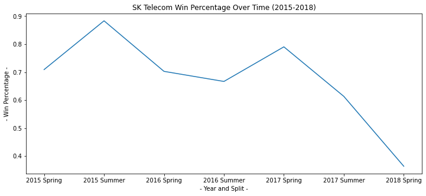

```python
#Creating the figure and resizing
f = plt.figure()
f.set_figwidth(12)
f.set_figheight(5)

#Plotting and Labeling
plt.plot(splits, splitWinRate)
plt.title(label = "SK Telecom Win Percentage Over Time (2015-2018)")
plt.xlabel(xlabel = " - Year and Split - ") #dashes help to distinguish axis label from seasons
plt.ylabel(ylabel = " - Win Percentage - ")
plt.show()
```

In order to do this, we will select a couple of other teams to analyze. The first one to use as a comparison will be the LCS (North America) region's Cloud Nine, a team that often finds itself not quite the best but often near the top of the region throughout the years. It will be interesting to compare SKT to a slightly more average team in what is often considered a more averagely competitive region than the upper tier Korean region. Additionally, we will analyze Team ROCCAT, a European team playing in what is referred to as the LEC. ROCCAT generally finds themselves near the bottom of the standings in what is generally a decent region, athough not quite as good as Korea or China.

First, I will begin by conducting a similar manipulation as above, but with Cloud 9 instead of SKT:

```python
#First, we create a new datatable by filtering for only matches where C9 is one of the teams
#C9 is blue team
blueC9 = data[data["blueTeamTag"] == "C9"]

#C9 is red team
redC9 = data[data["redTeamTag"] == "C9"]

#All C9 games
dataC9 = pd.concat([blueC9, redC9])

#Arrays to hold the count of wins in each split and games in each split
splitWinsC9 = []
splitGamesC9 = []
splitWinRateC9 = []

#Counting each split
for i in range(7):

    #Creating a subset for current split we are analyzing
    dataSplit = dataC9[dataC9["yearSplit"] == splits[i]]

    #Now begin calculating
    games = len(dataSplit.index) #number of rows or matches played
    blueGames = dataSplit[(dataSplit["blueTeamTag"] == "C9")] #subset where C9 was blue
    blueWins = blueGames[(blueGames["bResult"] == 1)] #subsetting when C9 won on blue side
    redGames = dataSplit[(dataSplit["redTeamTag"] == "C9")] #subset where C9 was red
    redWins = redGames[(redGames["rResult"] == 1)] #subsetting when C9 won on red side
    wins = len(blueWins.index) + len(redWins.index) #number of games won on either side
    winrate = wins / games #calculating the win ratio for the seaon

    #Adding calculated values into arrays created above
    splitWinsC9.append(wins)
    splitGamesC9.append(games)
    splitWinRateC9.append(winrate)

print("Splits: ")
print(splits)
print("Number of Games: ")
print(splitGamesC9)
print("Number of Wins: ")
print(splitWinsC9)
print("Winrate: ")
print(splitWinRateC9)
```

```
Splits:
['2015 Spring', '2015 Summer', '2016 Spring', '2016 Summer', '2017 Spring', '2017 Summer', '2018 Spring']
Number of Games:
[30, 43, 22, 73, 52, 70, 4]
Number of Wins:
[17, 20, 13, 44, 36, 40, 3]
Winrate:
[0.5666666666666667, 0.46511627906976744, 0.5909090909090909, 0.6027397260273972, 0.6923076923076923, 0.5714285714285714, 0.75]
```

We see here we have somewhat lower values for win ratios than the dominant SKT Team. We also notice similar issues with the number of datapoints in 2018, so we will likely not graph that year for our comparison. Next, we will conduct the manipulations necessary for Team ROCCAT and we can graph all the teams togther.

```python
#First, we create a new datatable by filtering for only matches where ROCCAT is one of the teams
#ROC is blue team
blueROC = data[data["blueTeamTag"] == "ROC"]

#ROC is red team
redROC = data[data["redTeamTag"] == "ROC"]

#All ROC games
dataROC = pd.concat([blueROC, redROC])

#Arrays to hold the count of wins in each split and games in each split
splitWinsROC = []
splitGamesROC = []
splitWinRateROC = []

#Counting each split
for i in range(7):

    #Creating a subset for current split we are analyzing
    dataSplit = dataROC[dataROC["yearSplit"] == splits[i]]

    #Now begin calculating
    games = len(dataSplit.index) #number of rows or matches played
    blueGames = dataSplit[(dataSplit["blueTeamTag"] == "ROC")] #subset where ROC was blue
    blueWins = blueGames[(blueGames["bResult"] == 1)] #subsetting when ROC won on blue side
    redGames = dataSplit[(dataSplit["redTeamTag"] == "ROC")] #subset where ROC was red
    redWins = redGames[(redGames["rResult"] == 1)] #subsetting when ROC won on red side
    wins = len(blueWins.index) + len(redWins.index) #number of games won on either side
    winrate = wins / games #calculating the win ratio for the seaon

    #Adding calculated values into arrays created above
    splitWinsROC.append(wins)
    splitGamesROC.append(games)
    splitWinRateROC.append(winrate)

print("Splits: ")
print(splits)
print("Number of Games: ")
print(splitGamesROC)
print("Number of Wins: ")
print(splitWinsROC)
print("Winrate: ")
print(splitWinRateROC)
```

```
Splits:
['2015 Spring', '2015 Summer', '2016 Spring', '2016 Summer', '2017 Spring', '2017 Summer', '2018 Spring']
Number of Games:
[18, 35, 18, 40, 40, 33, 4]
Number of Wins:
[6, 19, 4, 13, 20, 14, 3]
Winrate:
[0.3333333333333333, 0.5428571428571428, 0.2222222222222222, 0.325, 0.5, 0.42424242424242425, 0.75]
```

We can see that ROCCAT is quite a bit lower than the other teams most splits. We can view these trends even better by graphing all three teams to compare on a single figure:

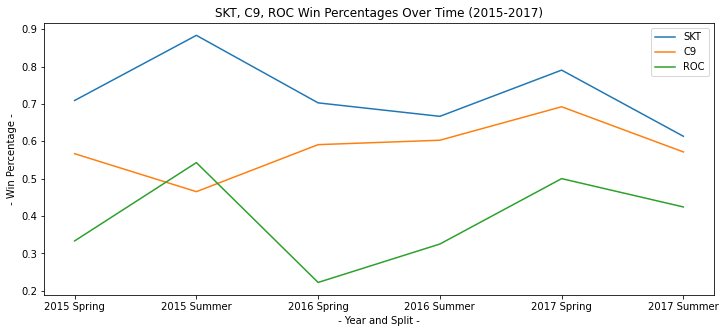

```python
#First, we want to drop that problematic last split from our comparison.
splits = splits[0:6]
splitWinRate = splitWinRate[0:6] #SKT
splitWinRateC9 = splitWinRateC9[0:6]
splitWinRateROC = splitWinRateROC[0:6]

#Creating the figure and resizing
f = plt.figure()
f.set_figwidth(12)
f.set_figheight(5)

#Plotting and Labeling
plt.plot(splits, splitWinRate, label = "SKT")
plt.plot(splits, splitWinRateC9, label = "C9")
plt.plot(splits, splitWinRateROC, label = "ROC")
plt.title(label = "SKT, C9, ROC Win Percentages Over Time (2015-2017)")
plt.xlabel(xlabel = " - Year and Split - ") #dashes help to distinguish axis label from seasons
plt.ylabel(ylabel = " - Win Percentage - ")
plt.legend()
plt.show()
```

This plot helps demonstrate just how good SK Telecom is. Even in their weakest splits, they generally still win a decent amount more than even a fairly good team from another region. A relatively poor team, cannot even compare at all to how winning SK Telecom is.

For another analysis, maybe we want to compare all the teams within just the Korean to show how SKT compares to their local competitors across the years. While similar to what we have done before, we have to do a little bit more manipulation to collect data from every team in the region in a smart way. Rather than creating an array for each team manually, we will use the Python dictionary feature to accumulate the win ratios for every team.

```python
#First, we subsection just games played within the LCK
dataLCK = data[ (data["League"] == "LCK") ]

#Now, we want to collect every unique team that played in the LCK from 2015 to 2018:
lckTeams = ["SKT"] #accumulator, SKT can already be included
for index, row in dataLCK.iterrows(): #this iterrates through our DataFrame

    if not (row["blueTeamTag"] in lckTeams) and not (row["Year"] == 2018):
        lckTeams.append(row["blueTeamTag"])

    if not (row["redTeamTag"] in lckTeams) and not (row["Year"] == 2018):
        lckTeams.append(row["redTeamTag"])

print("List of Every LCK Team: ")
print(lckTeams)
```

```
List of Every LCK Team:
['SKT', 'CJE', 'JAG', 'GET', 'NJE', 'IM', 'SSG', 'kt', 'ANC', 'SBENU', 'Longzhu', 'SSB', 'KOO', 'LZ', 'NJF', 'CJ', 'AFs', 'EMF', 'ROX', 'KDM', 'ESC', 'MVP', 'bbq', 'EEW', 'Winners', 'Prime', 'Xenics', 'DW', 'EVR', 'SBK']
```

Now, we want to use some Python looping to collect win statistics for us rather than having to calculate values for each team:

```python
#Not fully necessary but for clarity, we recreate the "splits" array we used before: (no 2018)
splits = ["2015 Spring", "2015 Summer", "2016 Spring", "2016 Summer",
          "2017 Spring", "2017 Summer"]

#Dictionary collector for winrates (one done already):
winRateDict = {"SKT": splitWinRate}

#Now we loop for every team in the LCK except SKT which is done already
for i in range(1, len(lckTeams)):

    team = lckTeams[i]
    #Subsetting games our current team is in
    blue = data[data["blueTeamTag"] == team]
    red = data[data["redTeamTag"] == team]

    #Array to hold the winrate in each split
    splitWinRates = []
    #Variable to hold the number of seasons a team had no games, will use to disclude teams with too little data
    seasonsNotPlayed = 0

    #Counting each split
    for j in range(6):

        #Creating a subset for current split we are analyzing
        blueSplit = blue[blue["yearSplit"] == splits[j]]
        redSplit = red[red["yearSplit"] == splits[j]]

        #Now begin calculating
        games = len(blueSplit.index) + len(redSplit.index)
        if not (games == 0): #avoiding divide by zero
            blueWins = blueSplit[(blueSplit["bResult"] == 1)] #subsetting when team won on blue side
            redWins = redSplit[(redSplit["rResult"] == 1)] #subsetting when team won on red side
            wins = len(blueWins.index) + len(redWins.index) #number of games won on either side
            winrate = wins / games #calculating the win ratio for the seaon
        else:
            seasonsNotPlayed += 1
            winrate = -0.1 #indicating that a team did not play differently from winning zero games

        #Adding calculated values into array created above
        splitWinRates.append(winrate)

    #Now we map this value into our dictionary, filtering out teams with no games in more than two seasons:
    if seasonsNotPlayed <= 1:
        winRateDict[team] = splitWinRates

#The full set is fairly messy, but we can print a few lines:
print("SKT: ")
print(winRateDict["SKT"])
print("SSG: ")
print(winRateDict["SSG"])
print("KT: ")
print(winRateDict["kt"])
```

```
SKT:
[0.7090909090909091, 0.8833333333333333, 0.7027027027027027, 0.6666666666666666, 0.7903225806451613, 0.6133333333333333]
SSG:
[0.1875, 0.425531914893617, 0.5, 0.6625, 0.6666666666666666, 0.6756756756756757]
KT:
[0.45454545454545453, 0.6071428571428571, 0.6304347826086957, 0.6290322580645161, 0.660377358490566, 0.5964912280701754]
```

A few of the teams' data have been outputted as an example. Note that for splits in which a team had no games, the winrate is listed as a negative value to distinguish from a potential team that played but won no games. With this data, we can now construct our plot for all the Korean teams:

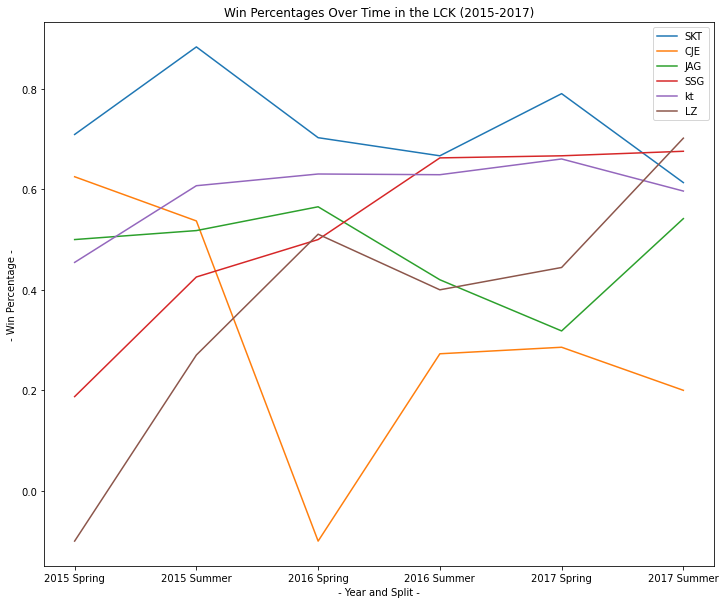

```python
#Creating the figure and resizing
f = plt.figure()
f.set_figwidth(12)
f.set_figheight(10)

#Iterrating through our dictionary, plotting and labeling
for team in winRateDict:
    plt.plot(splits, winRateDict[team], label = team)

plt.title(label = "Win Percentages Over Time in the LCK (2015-2017)")
plt.xlabel(xlabel = " - Year and Split - ") #dashes help to distinguish axis label from seasons
plt.ylabel(ylabel = " - Win Percentage - ")
plt.legend()
plt.show()
```

### **Analytical Hypothesis**

We have seen in our earlier analysis how dominant SK Telecom was during this time period, and it seems that they were always favorites when it came to tournament play. While this is somewhat true, they never managed to win every tournament there was during this time period. A human would likely struggle to analyze all the data points in our fairly expansive dataset. Additionally, if they analyzed a fairly limited quantifier as we did above, they might just pick SKT to win everything. To do better than this, we want to see if we can use a classifier to analyze a breadth of datapoints in our dataset and try to predict the winner of the next major tournament in a given season. Such tournaments would be the Mid Season Invitational for after Spring seasons and the World Championship after Summer. We can begin by separating the data for the 2015 Summer season, in which SKT did win World's shortly after.

```python
dataSummer15 = data[ (data["yearSplit"] == "2015 Summer") ]
dataSummer15
```

|  | League | Year | Season | Type | blueTeamTag | bResult | rResult | redTeamTag | gamelength | golddiff | ... | goldredMiddle | redADC | redADCChamp | goldredADC | redSupport | redSupportChamp | goldredSupport | redBans | Address | yearSplit |
| --- | --- | --- | --- | --- | --- | --- | --- | --- | --- | --- | --- | --- | --- | --- | --- | --- | --- | --- | --- | --- | --- |
| 92 | NALCS | 2015 | Summer | Season | C9 | 1 | 0 | TSM | 46 | [0, 0, -27, -108, -65, -349, -548, -440, -1047... | ... | [475, 475, 559, 868, 1174, 1501, 1844, 2108, 2... | WildTurtle | Urgot | [475, 475, 532, 783, 1120, 1411, 1780, 2074, 2... | Lustboy | Thresh | [515, 515, 577, 723, 874, 1007, 1201, 1340, 15... | ['Alistar', 'Sejuani', 'Ashe'] | http://matchhistory.na.leagueoflegends.com/en/... | 2015 Summer |
| 93 | NALCS | 2015 | Summer | Season | TDK | 0 | 1 | TL | 44 | [0, 10, 4, -56, 272, 98, 212, -59, 444, 483, -... | ... | [475, 475, 532, 836, 1166, 1534, 1809, 2144, 2... | Piglet | Kalista | [475, 475, 532, 873, 1102, 1349, 1677, 2032, 2... | Xpecial | Annie | [515, 515, 582, 735, 913, 1164, 1325, 1477, 16... | ['KogMaw', 'Nidalee', 'Evelynn'] | http://matchhistory.na.leagueoflegends.com/en/... | 2015 Summer |
| 94 | NALCS | 2015 | Summer | Season | CLG | 1 | 0 | DIG | 33 | [0, 0, 1, 52, 283, 202, 326, 186, 323, 410, 38... | ... | [475, 475, 552, 767, 1006, 1367, 1624, 1990, 2... | CoreJJ | Kalista | [475, 475, 532, 812, 1162, 1487, 1814, 2151, 2... | KiWiKiD | Annie | [515, 515, 583, 719, 860, 1009, 1166, 1320, 14... | ['Gragas', 'Leblanc', 'Bard'] | http://matchhistory.na.leagueoflegends.com/en/... | 2015 Summer |
| 95 | NALCS | 2015 | Summer | Season | T8 | 0 | 1 | TIP | 34 | [0, 10, 16, -322, -186, -317, -296, -520, -924... | ... | [475, 475, 532, 762, 1037, 1338, 1503, 1863, 2... | Apollo | Sivir | [475, 475, 532, 847, 1167, 1463, 1674, 2014, 2... | Adrian | Alistar | [515, 515, 591, 759, 905, 1077, 1226, 1412, 15... | ['Gragas', 'Maokai', 'Leblanc'] | http://matchhistory.na.leagueoflegends.com/en/... | 2015 Summer |
| 96 | NALCS | 2015 | Summer | Season | GV | 0 | 1 | NME | 43 | [40, 40, 44, 41, -39, -209, 327, 245, 353, 200... | ... | [475, 475, 532, 771, 1128, 1458, 1960, 2131, 2... | otter | Vayne | [475, 475, 532, 898, 1204, 1494, 1761, 2122, 2... | Bodydrop | Nautilus | [515, 515, 577, 748, 877, 1025, 1229, 1414, 15... | ['Alistar', 'RekSai', 'Gragas'] | http://matchhistory.na.leagueoflegends.com/en/... | 2015 Summer |
| ... | ... | ... | ... | ... | ... | ... | ... | ... | ... | ... | ... | ... | ... | ... | ... | ... | ... | ... | ... | ... | ... |
| 7417 | LCK | 2015 | Summer | Promotion | SSG | 1 | 0 | Xenics | 37 | [0, 0, 3, 110, 235, -771, -344, -355, -664, -4... | ... | [475, 475, 532, 781, 1041, 1563, 1697, 2057, 2... | LuNar | Sivir | [475, 475, 552, 881, 1116, 1412, 1654, 1952, 2... | TML | Nautilus | [515, 515, 576, 749, 916, 1069, 1213, 1357, 15... | ['Nidalee', 'Kalista', 'RekSai'] | http://matchhistory.na.leagueoflegends.com/en/... | 2015 Summer |
| 7418 | LCK | 2015 | Summer | Promotion | Xenics | 0 | 1 | SSG | 48 | [0, 0, 5, 100, -105, 126, 33, 17, 277, 159, -1... | ... | [475, 475, 532, 786, 1091, 1331, 1634, 1959, 2... | Fury | Sivir | [475, 475, 532, 736, 1061, 1403, 1650, 1943, 2... | Wraith | Alistar | [515, 515, 572, 686, 851, 965, 1079, 1234, 134... | ['Cassiopeia', 'Azir', 'RekSai'] | http://matchhistory.na.leagueoflegends.com/en/... | 2015 Summer |
| 7419 | LCK | 2015 | Summer | Promotion | Prime | 0 | 1 | Xenics | 50 | [0, 0, -26, 109, 299, 40, -131, 99, -274, -311... | ... | [475, 475, 532, 786, 1111, 1468, 1761, 2092, 2... | LuNar | Jinx | [475, 475, 552, 816, 1081, 1473, 1781, 2137, 2... | TML | Morgana | [515, 515, 583, 772, 913, 1076, 1236, 1393, 15... | ['Kalista', 'Leblanc', 'Lulu'] | http://matchhistory.na.leagueoflegends.com/en/... | 2015 Summer |
| 7420 | LCK | 2015 | Summer | Promotion | Xenics | 0 | 1 | Prime | 56 | [0, 0, -47, -61, 44, 305, 261, 88, 174, 2, -14... | ... | [475, 475, 552, 801, 1061, 1393, 1721, 2052, 2... | Nuclear | Lucian | [475, 475, 532, 781, 1086, 1281, 1645, 1974, 2... | Secret | Nautilus | [515, 515, 577, 787, 959, 1105, 1277, 1430, 15... | ['Cassiopeia', 'Hecarim', 'RekSai'] | http://matchhistory.na.leagueoflegends.com/en/... | 2015 Summer |
| 7421 | LCK | 2015 | Summer | Promotion | Prime | 1 | 0 | Xenics | 44 | [0, 0, -6, -156, -108, -86, -44, -174, -382, 1... | ... | [475, 475, 532, 856, 1111, 1428, 1756, 2024, 2... | LuNar | KogMaw | [475, 475, 532, 776, 1111, 1453, 1746, 2101, 2... | TML | Morgana | [515, 515, 582, 717, 893, 1058, 1238, 1391, 15... | ['Leblanc', 'Kalista', 'Maokai'] | http://matchhistory.na.leagueoflegends.com/en/... | 2015 Summer |

837 rows × 58 columns

One interesting thing to notice is the "Type" column. There are a multitude of different categories this set has including Season, Playoff, Regional, and International games. For our prediction analysis, we wish to remove rows listed as International play for training since the point of our classification is to predict the result of these tournaments. The column description that was created early on does not list it, but we can also see Promotion games above. These are games played in which teams are fighting to either take or retain the bottom place spot within a region. While miracles sometimes come true, we can remove these games from our dataset as essentially half the teams never actually make it to high level professional leagues and the other half are at the bottom. The games also are also generally outside of regular play so we probably would not analyze them anyways. These rows are removed below:

```python
#Subsetting to remove rows we stated we do not wish to have
predictionData = dataSummer15[ (dataSummer15["Type"]) != "International"]
predictionData = predictionData[ (predictionData["Type"]) != "Promotion"]
predictionData
```

|  | League | Year | Season | Type | blueTeamTag | bResult | rResult | redTeamTag | gamelength | golddiff | ... | goldredMiddle | redADC | redADCChamp | goldredADC | redSupport | redSupportChamp | goldredSupport | redBans | Address | yearSplit |
| --- | --- | --- | --- | --- | --- | --- | --- | --- | --- | --- | --- | --- | --- | --- | --- | --- | --- | --- | --- | --- | --- |
| 92 | NALCS | 2015 | Summer | Season | C9 | 1 | 0 | TSM | 46 | [0, 0, -27, -108, -65, -349, -548, -440, -1047... | ... | [475, 475, 559, 868, 1174, 1501, 1844, 2108, 2... | WildTurtle | Urgot | [475, 475, 532, 783, 1120, 1411, 1780, 2074, 2... | Lustboy | Thresh | [515, 515, 577, 723, 874, 1007, 1201, 1340, 15... | ['Alistar', 'Sejuani', 'Ashe'] | http://matchhistory.na.leagueoflegends.com/en/... | 2015 Summer |
| 93 | NALCS | 2015 | Summer | Season | TDK | 0 | 1 | TL | 44 | [0, 10, 4, -56, 272, 98, 212, -59, 444, 483, -... | ... | [475, 475, 532, 836, 1166, 1534, 1809, 2144, 2... | Piglet | Kalista | [475, 475, 532, 873, 1102, 1349, 1677, 2032, 2... | Xpecial | Annie | [515, 515, 582, 735, 913, 1164, 1325, 1477, 16... | ['KogMaw', 'Nidalee', 'Evelynn'] | http://matchhistory.na.leagueoflegends.com/en/... | 2015 Summer |
| 94 | NALCS | 2015 | Summer | Season | CLG | 1 | 0 | DIG | 33 | [0, 0, 1, 52, 283, 202, 326, 186, 323, 410, 38... | ... | [475, 475, 552, 767, 1006, 1367, 1624, 1990, 2... | CoreJJ | Kalista | [475, 475, 532, 812, 1162, 1487, 1814, 2151, 2... | KiWiKiD | Annie | [515, 515, 583, 719, 860, 1009, 1166, 1320, 14... | ['Gragas', 'Leblanc', 'Bard'] | http://matchhistory.na.leagueoflegends.com/en/... | 2015 Summer |
| 95 | NALCS | 2015 | Summer | Season | T8 | 0 | 1 | TIP | 34 | [0, 10, 16, -322, -186, -317, -296, -520, -924... | ... | [475, 475, 532, 762, 1037, 1338, 1503, 1863, 2... | Apollo | Sivir | [475, 475, 532, 847, 1167, 1463, 1674, 2014, 2... | Adrian | Alistar | [515, 515, 591, 759, 905, 1077, 1226, 1412, 15... | ['Gragas', 'Maokai', 'Leblanc'] | http://matchhistory.na.leagueoflegends.com/en/... | 2015 Summer |
| 96 | NALCS | 2015 | Summer | Season | GV | 0 | 1 | NME | 43 | [40, 40, 44, 41, -39, -209, 327, 245, 353, 200... | ... | [475, 475, 532, 771, 1128, 1458, 1960, 2131, 2... | otter | Vayne | [475, 475, 532, 898, 1204, 1494, 1761, 2122, 2... | Bodydrop | Nautilus | [515, 515, 577, 748, 877, 1025, 1229, 1414, 15... | ['Alistar', 'RekSai', 'Gragas'] | http://matchhistory.na.leagueoflegends.com/en/... | 2015 Summer |
| ... | ... | ... | ... | ... | ... | ... | ... | ... | ... | ... | ... | ... | ... | ... | ... | ... | ... | ... | ... | ... | ... |
| 4518 | TCL | 2015 | Summer | Playoffs | BJK | 0 | 1 | DP | 42 | [0, 0, -34, -46, -66, -166, -120, 484, 558, 65... | ... | [475, 475, 572, 816, 1148, 1432, 1761, 2051, 2... | Zeitnot | Vayne | [475, 475, 532, 806, 1142, 1462, 1775, 1982, 2... | Rydle | Alistar | [515, 515, 577, 720, 844, 1005, 1150, 1294, 14... | ['Ryze', 'Bard', 'Kalista'] | http://matchhistory.tr.leagueoflegends.com/en/... | 2015 Summer |
| 4519 | TCL | 2015 | Summer | Playoffs | DP | 1 | 0 | BJK | 38 | [0, 0, 14, -4, -22, -29, 73, -14, 149, -120, -... | ... | [475, 475, 533, 791, 1127, 1444, 1742, 2051, 2... | Nardeus | Kalista | [475, 475, 533, 898, 1274, 1631, 1863, 2182, 2... | Dumbledoge | Morgana | [515, 515, 584, 729, 877, 1038, 1191, 1334, 15... | ['Fizz', 'Alistar', 'Gragas'] | http://matchhistory.tr.leagueoflegends.com/en/... | 2015 Summer |
| 4520 | TCL | 2015 | Summer | Playoffs | BJK | 1 | 0 | DP | 41 | [0, 0, -5, -605, -678, -364, -494, -501, -774,... | ... | [475, 475, 557, 830, 1253, 1565, 2002, 2408, 2... | Zeitnot | Kalista | [475, 475, 532, 1061, 1417, 1703, 2122, 2292, ... | Rydle | Braum | [515, 515, 577, 848, 973, 1131, 1294, 1519, 16... | ['Ryze', 'Bard', 'Shen'] | http://matchhistory.tr.leagueoflegends.com/en/... | 2015 Summer |
| 4521 | TCL | 2015 | Summer | Playoffs | DP | 1 | 0 | BJK | 34 | [0, 0, 66, -157, -92, -56, 155, 140, 210, -408... | ... | [475, 475, 533, 857, 1147, 1428, 1736, 2036, 2... | Nardeus | Corki | [475, 475, 547, 841, 1135, 1492, 1754, 2136, 2... | Dumbledoge | Trundle | [515, 515, 578, 743, 892, 1018, 1248, 1415, 16... | ['Azir', 'Fizz', 'Alistar'] | http://matchhistory.tr.leagueoflegends.com/en/... | 2015 Summer |
| 7057 | LMS | 2015 | Summer | Season | HKE | 1 | 0 | TPA | 35 | [0, 10, 42, 7, -124, -82, -398, -234, 368, 158... | ... | [475, 475, 532, 806, 1172, 1407, 1867, 2181, 2... | Lupin | Lucian | [475, 475, 532, 856, 1166, 1513, 2143, 2288, 2... | Jay | Thresh | [515, 515, 577, 700, 883, 1026, 1291, 1414, 15... | ['Ryze', 'Azir'] | http://matchhistory.na.leagueoflegends.com/en/... | 2015 Summer |

706 rows × 58 columns

In doing this, we managed to filter out around 130 rows from our table or around 1/6 of the matches. We can further clean up our dataset by removing some uneccessary columns, however this will be done a bit later simply by exlusion when we manipulate our data later.

To begin actually doing some classifying and prediction, we want to fit a Regression using tools from SciKit Learn (SKLearn). Before we can do that, we need to reformutate our dataset in a way that makes sense for our prediction. Rather than having each row in our table be a single match, we want to make each row be some form of wholistic data summarizing key statistics across the season for one team:

- The first we can start off with is winrate, as we have calculated above
- Next, we likely want to include teams' home region, reformatted to a numerical form for SKLearn
- We might want to calculate the average game time for a team, perhaps also calculating separate averages for wins and losses

While not in this analysis, for a future analysis we might want to:

- Include the player who played each role for most of the season
- Calculate most banned champion or two across the season from the bans column
- Calculate most played champion in each role
- Calculate average gold difference or average total gold at each minute or key points throughout the game

Before calculating different averages across the season for each team, we want to get rid of the need for a red or blue side designation, since it complicates our analysis. We will break the table into red and blue side data, then concatenate them into one table without the side designations. This will go as follows:

```python
df = predictionData.copy(deep = True) #makes our statements below a bit simpler

bluePredictionData = pd.DataFrame().assign(League=df['League'], Type=df['Type'], TeamTag=df['blueTeamTag'], Result=df['bResult'],
                                          GameLength = df['gamelength'])

redPredictionData = pd.DataFrame().assign(League=df['League'], Type=df['Type'], TeamTag=df['redTeamTag'], Result=df['rResult'],
                                          GameLength = df['gamelength'])

newPredData = pd.concat([bluePredictionData, redPredictionData])
newPredData
```

|  | League | Type | TeamTag | Result | GameLength |
| --- | --- | --- | --- | --- | --- |
| 92 | NALCS | Season | C9 | 1 | 46 |
| 93 | NALCS | Season | TDK | 0 | 44 |
| 94 | NALCS | Season | CLG | 1 | 33 |
| 95 | NALCS | Season | T8 | 0 | 34 |
| 96 | NALCS | Season | GV | 0 | 43 |
| ... | ... | ... | ... | ... | ... |
| 4518 | TCL | Playoffs | DP | 1 | 42 |
| 4519 | TCL | Playoffs | BJK | 0 | 38 |
| 4520 | TCL | Playoffs | DP | 0 | 41 |
| 4521 | TCL | Playoffs | BJK | 0 | 34 |
| 7057 | LMS | Season | TPA | 0 | 35 |

1412 rows × 5 columns

We now have double the rows and a much easier DataFrame to analyze. We can soon begin calculating some of our averages, but first we want to collect the list of every team we have.

```python
teams = ["C9", "SKT"] #just adding a couple

for index, row in newPredData.iterrows():

    if not (row["TeamTag"]) in teams:
        teams.append(row["TeamTag"])

print(teams[0:8]) # first few elements
```

```
['C9', 'SKT', 'TDK', 'CLG', 'T8', 'GV', 'TL', 'DIG']
```

We will create our final DataFrame to analyze now that will be updated with averages for each team across the season. Columns will include:

- Team Home Region
- Did team have any playoff games?
- Team's average winrate
- Team's average game time
- Team's average win time
- Team's average loss time

We will also include a teams wins. We want to see if the algorithm can correctly fit a prediction to the number of wins a team would have. Our goal was to predict a tournament winner on a global stage following a season. Well, who will win the most in a pool of all the global teams essentially gives us the same result, since to win a tournament you must win the most games.

```python
#dictionary to create our dataframe from
statsDict = {"Team" : teams, "Region": [], "InPlayoffs" : [], "Wins" : [], "Winrate": [],
           "AverageGameTime" : [], "AverageWinTime" : [], "AverageLossTime" : [] }


numTeams = len(teams)
for i in range (numTeams) :

    #accumulators to create averages
    games = 0
    wins = 0
    totalGameTime = 0
    totalWinTime = 0
    totalLossTime = 0
    playoffs = 0
    homeRegion = ""

    for index, row in newPredData.iterrows():

        #if we find our current team
        if row["TeamTag"] == teams[i]:
            homeRegion = row["League"]
            games += 1
            totalGameTime += row["GameLength"]

            #if team won
            if row["Result"] == 1:
                wins += 1
                totalWinTime += row["GameLength"]
            else:
                totalLossTime += row["GameLength"]

            if row["Type"] == "Playoffs":
                playoffs = 1;

    winrate = wins / games
    avTime = totalGameTime / games
    if wins > 0:
        avWin = totalWinTime / wins
    else:
        avWin = 200; #if they never win, average wintime is some large num outside normal range
    avLoss = totalLossTime / (games - wins)

    statsDict["Region"].append(homeRegion)
    statsDict["InPlayoffs"].append(playoffs)
    statsDict["Wins"].append(wins)
    statsDict["Winrate"].append(winrate)
    statsDict["AverageGameTime"].append(avTime)
    statsDict["AverageWinTime"].append(avWin)
    statsDict["AverageLossTime"].append(avLoss)

#Creating our dataframe from our dictionary
finalPredData = pd.DataFrame.from_dict(statsDict)

#Going to need to make the regions numeric:
regionCodes = {"LCK" : 1, "LMS" : 2, "EULCS" : 3, "NALCS" : 4, "TCL" : 5}
finalPredData["Region"] = finalPredData["Region"].replace(regionCodes)


finalPredData = finalPredData.sort_values(by = ["Winrate", "Region"], ascending = False)
finalPredData.head()
```

|  | Team | Region | InPlayoffs | Wins | Winrate | AverageGameTime | AverageWinTime | AverageLossTime |
| --- | --- | --- | --- | --- | --- | --- | --- | --- |
| 18 | FNC | 3 | 1 | 24 | 0.923077 | 36.346154 | 35.833333 | 42.500000 |
| 40 | ahq | 2 | 1 | 28 | 0.903226 | 37.322581 | 37.428571 | 36.333333 |
| 1 | SKT | 1 | 1 | 38 | 0.863636 | 37.204545 | 36.552632 | 41.333333 |
| 3 | CLG | 4 | 1 | 19 | 0.760000 | 37.360000 | 37.578947 | 36.666667 |
| 50 | DP | 5 | 1 | 15 | 0.750000 | 38.150000 | 37.800000 | 39.200000 |

Now that we have properly adjusted our dataset, lets begin trying to make some predictions. First, we want to decide what our Null Hypothesis is. The Null Hypothesis will be accepted or rejected depending on the statistical analysis of whatever classification we decide to use. For this analysis, the Null Hypothesis is that there is no significant statistical significance between our data and the team which will win the next international tournament.

We them want to finally use our SKLearn tools to fit a regression onto our data.

```python
y = finalPredData["Wins"].to_numpy()
x = finalPredData.drop(columns = ["Wins", "Team"]).to_numpy()
model = LinearRegression().fit(x, y)

# Print the Intercept:
print('Intercept:', model.intercept_)

# Print the Slope:
print('Slope:', model.coef_)

print("Sample Prediction, SKT Stats: ")
print(model.predict([[1, 1, 0.863, 37.2, 36.553, 41.3333]]))
```

```
Intercept: -2.6304078134242346
Slope: [-2.59559077e+00  4.44702447e+00  2.94606005e+01  3.26909762e-01
 -5.58154732e-03 -1.14683102e-01]
Sample Prediction, SKT Stats:
[31.86231392]
```

What is interesting to notice is that using our regression, and inserting SKT's statistics, we predict that they will win 31 games. By checking in our DataFrame above, however, we can see that SKT actually won 38 games, a whole 7 more than predicted. Let's now go ahead and apply our predictions to our dataset:

```python
predictions = model.predict(x) #predicting using our regression on all our data rows

t = finalPredData["Team"].to_numpy() #creating an array of teams

#Creating a DataFrame to store our values
dataDict = {"Team" : t, "WinsPredicted" : predictions}
predictionFrame = pd.DataFrame.from_dict(dataDict)
predictionFrame = predictionFrame.sort_values(by = "WinsPredicted", ascending = False)
predictionFrame.head(10)
```

|  | Team | WinsPredicted |
| --- | --- | --- |
| 2 | SKT | 31.882546 |
| 1 | ahq | 31.060397 |
| 0 | FNC | 28.032120 |
| 12 | kt | 25.570423 |
| 11 | KOO | 25.209089 |
| 5 | FW | 24.964605 |
| 17 | CJE | 23.069432 |
| 21 | NJF | 22.639727 |
| 13 | HKE | 22.224127 |
| 3 | CLG | 21.622863 |

Only the top few teams were outputted, now we can compare this to the actual top teams. From https://lol.fandom.com/wiki/2015_Season_World_Championship we can see a chart of the placements of each team in the tournament.

```python
worldsDict = {"Team" : ["SKT", "KOO", "OG", "FNC", "FW", "ahq", "EDG",
                        "kt", "H2K", "LGD", "C9", "CLG", "PNG", "BKT", "TSM", "IG"],
             "Place" : list(range(1, 17))}

worldsData = pd.DataFrame.from_dict(worldsDict)
worldsData.head(10)
```

|  | Team | Place |
| --- | --- | --- |
| 0 | SKT | 1 |
| 1 | KOO | 2 |
| 2 | OG | 3 |
| 3 | FNC | 4 |
| 4 | FW | 5 |
| 5 | ahq | 6 |
| 6 | EDG | 7 |
| 7 | kt | 8 |
| 8 | H2K | 9 |
| 9 | LGD | 10 |

We see here that besides predicting the overall winner, our predictions are generally off from team's actual placement by a few places. We can also more formally test the statistical accuraccy of our regression. First, we want to ensure that the teams lign up rather than being ordered by wins.

```python
actualWinData = finalPredData.copy(deep = True).drop(columns = ["Winrate", "InPlayoffs", "Region", "AverageGameTime", "AverageWinTime", "AverageLossTime"])
actualWinData = actualWinData.sort_values(by = "Team", ascending = False)
predictionFrame = predictionFrame.sort_values(by = "Team", ascending = False)
actualWinData.head(14)
```

|  | Team | Wins |
| --- | --- | --- |
| 26 | kt | 34 |
| 35 | as | 0 |
| 40 | ahq | 28 |
| 11 | UOL | 12 |
| 49 | TT | 12 |
| 9 | TSM | 17 |
| 37 | TPA | 13 |
| 6 | TL | 19 |
| 8 | TIP | 19 |
| 2 | TDK | 3 |
| 4 | T8 | 6 |
| 23 | SSG | 16 |
| 29 | SSB | 8 |
| 1 | SKT | 38 |

```python
predictionFrame.head(14)
```

|  | Team | WinsPredicted |
| --- | --- | --- |
| 12 | kt | 25.570423 |
| 49 | as | -1.085512 |
| 1 | ahq | 31.060397 |
| 33 | UOL | 13.076042 |
| 20 | TT | 12.167704 |
| 14 | TSM | 17.582304 |
| 29 | TPA | 11.668203 |
| 10 | TL | 17.604903 |
| 15 | TIP | 15.360657 |
| 47 | TDK | 0.603218 |
| 39 | T8 | 4.842938 |
| 34 | SSG | 14.080236 |
| 46 | SSB | 9.029681 |
| 2 | SKT | 31.882546 |

```python
pred = predictionFrame["WinsPredicted"].to_numpy().tolist()
actual = actualWinData["Wins"].to_numpy().tolist()

print("Error = ", mean_squared_error(actual,pred))
```

```
Error =  18.51530724214066
```

We can see here that the error in our model is very high. However, this error is showing how the predicted number of wins differs from the number of wins a team actually got during their overall *season* rather than on the international stage. For our desired purpose, we seem to have at least somewhat predicted teams that would do well, although definitely not to a very exact degree. One potential flaw that can be pointed out from above is that Korean teams across the board tend to have larger amounts of wins. This could be due to league structure, playing either more regular season or playoff games simply due to differences in the way the independent leagues work.

Due to the very high degree of error, we can likely conclude that we do not have a significant correlation between our data and the actual wins a team will achieve nor are we accurately predicting how teams will place in tournaments. Due to this, we will have to accept the previously mentioned Null Hypothesis. Had we noticed a somewhat greater trend in the data, we may have found it to be interesting and worthwhile to apply our modeling methods to other seasons to try and predict the wins of other teams. We did, however, manage to predict at least the very top team with this model. This is likely a result of the most winning team simply being whoever won the most in a region that plays more games.

## **Insights Gained**

Analyzing the methods and results of our created model, I would argue that the qualification used for the "top team" would definitely have to change. The goal of the analysis was to predict how teams would do in the next major tournament, so it seemed to make sense to pick whoever wins the most as the best team. However, we see from our data that different leagues play different number of games so this might not be an accurate way to judge who is the best. We also might want to find ways to include many more attribute that were listed above. For example, Gold is a very important part of the game, and Gold Differences are often how casters and fans judge who is winning a game while it is live. While the dataset's format might have made averaging gold differences somewhat difficult, either retrieving this information from another source or wrangling from the dataset would likely have proved very useful. Overall, there was some success in predicting the tournament success of teams from the dataset, however it is clear that you can never truly tell how all the teams will do. This makes sense, however, since there would be no need to play the games out if we could already tell who was going to win.